# Power Analysis for CSI online typing with patients with aphasia - Control cohort: Analyse the power for the interactoion effect Interaction effect: Session x Ordinal position with 20 participant

Kirsten Stark

09 Dezember, 2021

# load packages

```r
library(tidyr)
library(dplyr)
library(devtools)
library(MASS)
library(lme4)
library(lmerTest)
library(simr)
library(pbkrtest)
library(testthat)
library(ggplot2)

rm(list = ls())

today <- Sys.Date()
today <- format(today, format="%d%m%y")
```

# Load data from Stark, van Scherpenberg, Obrig, & Abdel Rahman (2021, Experiment 1)

In this online study, we tested 30 young, neurotypical participants with the same paradigm and stimuli as in the current experiment. Now we would like to analyse the effect of the session on the CSI-effect. To this end, we will have to generate data for the second and third session, assuming that the variances will be comparable in the three sessions.

```r
# Set number of iterations
n_iter = 1000

# set seed
set.seed(99)

# load data
input = "Starketal_CSI_online_combined.csv"
df <- read.csv(here::here("data", "power-analysis", input))

# do some transformations
df <- df %>%
  # filter spoken naming only
  filter(df$experiment == "verbal") %>%
  # factorize columns
  mutate(subject = as.factor(subject),
         category=as.factor(category),
         experiment=as.factor(experiment)) %>%
  # make sure RTs are numeric
  mutate(RT = as.numeric(as.character(RT)))
```

## A) Interaction effect when the session main effect is 40 ms

Now we need to generate data for the second and third session

```r
# 1) We increase the length of the data set by 3 and add the column session
n_obs = nrow(df)
df <- rbind(df, df , df)
df %>% mutate(session = rep(c(1,2,3), each=n_obs)) -> df

# 2) To prevent linear dependencies, we need to introduce some jitter in the RT data for session 2 and 3
    # generate n_obs random numbers from a normal distribution and add them to the data
    # at first we implement a difference of 40 ms between session 1 and 2 and session 2 and 3, and a variance of 20 and 30
rand1 = rnorm(n_obs, mean = 40, sd = 20)
rand2 = rnorm(n_obs, mean = 80, sd = 30)

df %>% mutate(RT = case_when(session == 1 ~ RT,
                             session == 2 ~ RT + rand1,
                             session == 3 ~ RT + rand2),
              session = as.factor(session)) %>% droplevels() -> df

# Plot the results
summary <- df %>%
   Rmisc::summarySEwithin(.,"RT",idvar = "subject",
                          withinvars = c("Pos", "session"),
                          na.rm = T)
```

```
## Automatically converting the following non-factors to factors: Pos
```

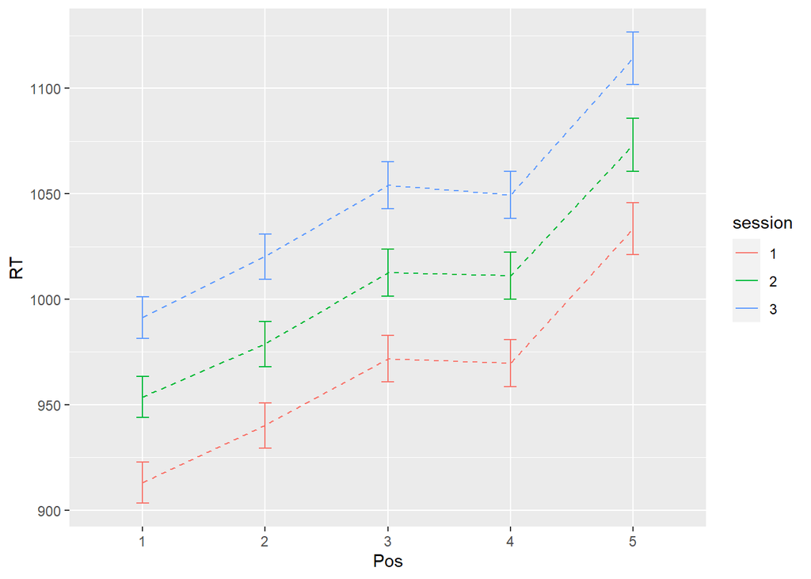

```r
ggplot(data=summary, aes(x=Pos, y=RT, group=session,
                         color = session)) +
    geom_line(aes(y = RT),
              size = 0.5, linetype = "dashed")+
    geom_errorbar(aes(ymin=RT-se, ymax=RT+se), width =.1)
```

## 1) Set up a model based on the structure of the planned CSI experiment

Unfortunately, simr does not work properly with GLMMs. Therefore, for the power analysis, we will set up an LMM with transformed RTs  
a) center OrdPos (continuous predictor)

```r
# center continuous predictor
df %>% mutate(Pos.c=scale(as.numeric(as.character(Pos)),
                     center = TRUE, scale = FALSE)) -> df
```

2. Check distribution of RTs

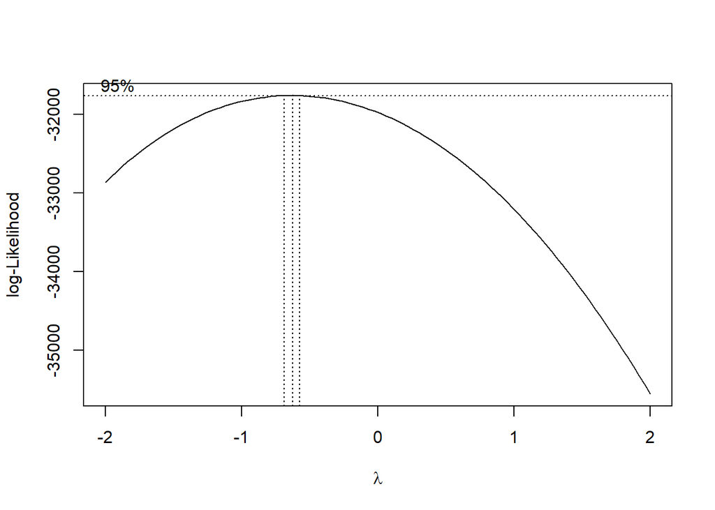

```r
# Boxcox plot suggests inverse transformation:
boxcox(df$RT ~ df$Pos*df$session)
```

Check the goodness of fit of an inverse transformation (with RT divided by 1000: 1/(x/1000) = 1000/x):

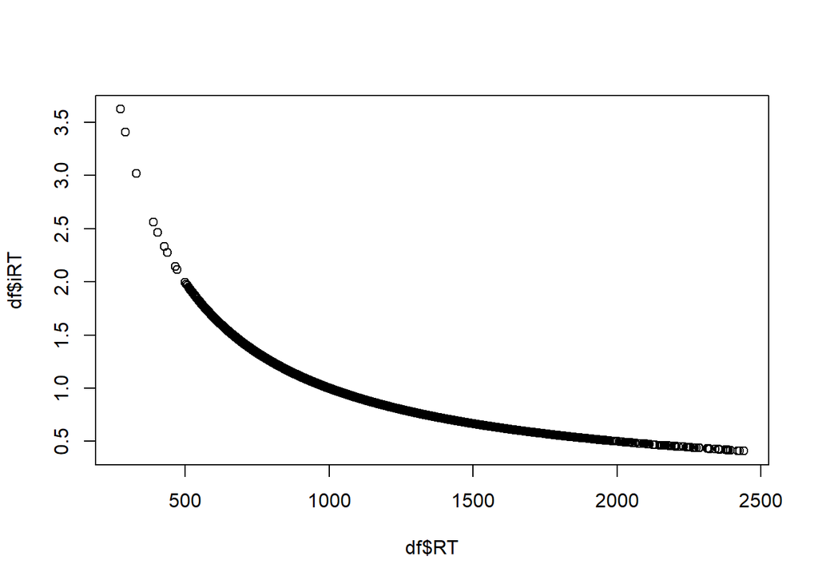

```r
df$iRT <-1000/df$RT
# plot this transformation distribution
plot(df$RT, df$iRT)
```

```r
# check fit
fit.normal_inv<- fitdistrplus::fitdist(
  df$iRT, distr = "norm", method = "mle")
summary(fit.normal_inv)
```

```
## Fitting of the distribution ' norm ' by maximum likelihood
## Parameters :
##       estimate  Std. Error
## mean 1.0698881 0.002777207
## sd   0.2748173 0.001963665
## Loglikelihood:  -1246.42   AIC:  2496.84   BIC:  2511.219
## Correlation matrix:
##      mean sd
## mean    1  0
## sd      0  1
```

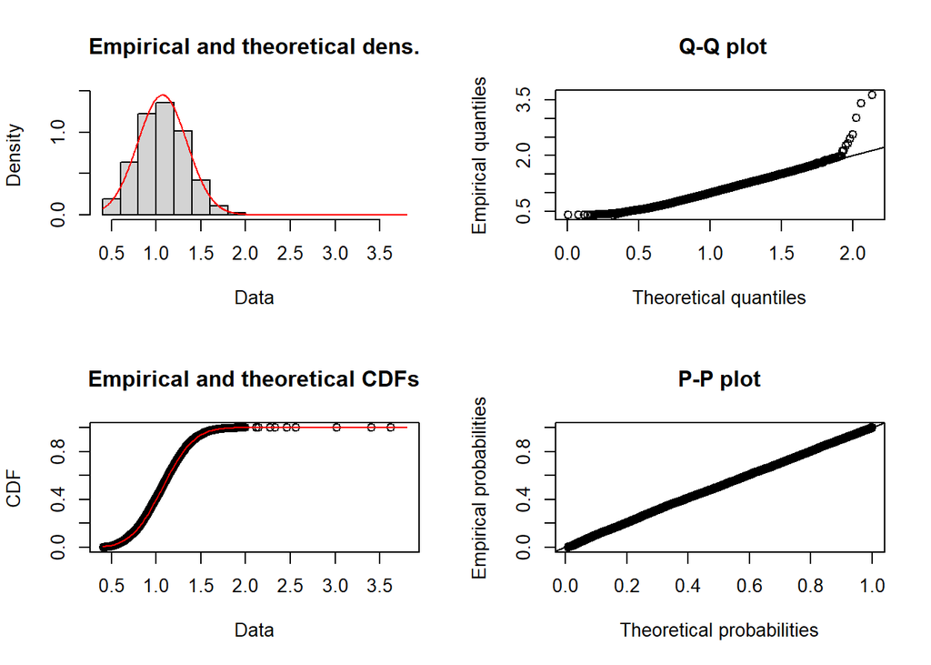

```r
plot(fit.normal_inv)
```

An inverse transformation fits the data relatively well. We will thus use this kind of transformation

3. Set up the models

*Model 1: Linear model with continuous predictor “Ordinal position”, sliding difference contrasted predictor “session” and inversely transformed RT data*

```r
# compute sliding difference contrast: Intercept is grand mean, second level is compared to first level
contrasts(df$session) <- contr.sdif(3)
# maximal model has singular fit - stepwise reduction
# lmm1 <- lmer(iRT ~ Pos.c*session +
#               (Pos.c*session|subject) +(Pos.c*session|category) ,
#            data = df, REML = FALSE,
#            control=lmerControl(optimizer = "bobyqa"))
# lmm1 <- lmer(iRT ~ Pos.c*session +
#               (Pos.c*session|subject) +(Pos.c*session|category) ,
#            data = df, REML = FALSE,
#            control=lmerControl(optimizer = "bobyqa",
#                                 optCtrl=list(maxfun=2e5)))
lmm1 <- lmer(iRT ~ Pos.c*session +
              (Pos.c|subject) +(Pos.c|category) ,
           data = df, REML = FALSE,
           control=lmerControl(optimizer = "bobyqa",
                                optCtrl=list(maxfun=2e5)))

isSingular(lmm1)
```

```
## [1] FALSE
```

```r
summary(lmm1)
```

```
## Linear mixed model fit by maximum likelihood . t-tests use Satterthwaite's
##   method [lmerModLmerTest]
## Formula: iRT ~ Pos.c * session + (Pos.c | subject) + (Pos.c | category)
##    Data: df
## Control: lmerControl(optimizer = "bobyqa", optCtrl = list(maxfun = 2e+05))
##
##      AIC      BIC   logLik deviance df.resid
##   -722.0   -628.6    374.0   -748.0     9779
##
## Scaled residuals:
##     Min      1Q  Median      3Q     Max
## -3.3644 -0.6202  0.0335  0.6362  9.9337
##
## Random effects:
##  Groups   Name        Variance  Std.Dev. Corr
##  subject  (Intercept) 0.0109747 0.10476
##           Pos.c       0.0003202 0.01789  -0.30
##  category (Intercept) 0.0085983 0.09273
##           Pos.c       0.0003377 0.01838  0.28
##  Residual             0.0525453 0.22923
## Number of obs: 9792, groups:  subject, 30; category, 24
##
## Fixed effects:
##                    Estimate Std. Error         df t value Pr(>|t|)
## (Intercept)       1.061e+00  2.701e-02  5.178e+01  39.298  < 2e-16 ***
## Pos.c            -2.689e-02  5.241e-03  4.198e+01  -5.130 6.99e-06 ***
## session2-1       -5.051e-02  5.674e-03  9.685e+03  -8.901  < 2e-16 ***
## session3-2       -4.606e-02  5.674e-03  9.685e+03  -8.117 5.38e-16 ***
## Pos.c:session2-1  2.294e-03  4.020e-03  9.685e+03   0.571    0.568
## Pos.c:session3-2  1.403e-03  4.020e-03  9.685e+03   0.349    0.727
## ---
## Signif. codes:  0 '***' 0.001 '**' 0.01 '*' 0.05 '.' 0.1 ' ' 1
##
## Correlation of Fixed Effects:
##             (Intr) Pos.c  sss2-1 sss3-2 P.:2-1
## Pos.c        0.008
## session2-1   0.000  0.000
## session3-2   0.000  0.000 -0.500
## Ps.c:sss2-1  0.000  0.000  0.000  0.000
## Ps.c:sss3-2  0.000  0.000  0.000  0.000 -0.500
```

### 2) Extend dataset

In this case we want less subjects than in the previous study, so we do not need to extend.

### 3) Specify effect sizes for the interaction effect and compute power analyses

To specify the effect sizes, we always take the grand mean and take +- 1/2 the inversely transformed difference we want to implement. We keep the two main effects unchanged.

#### 15 ms interaction effect, 20 VP

```r
gm <- mean(df$RT)
eff_15ms <- (1000/(gm+(15/2))) - (1000/(gm-(15/2)))
fixef(lmm1)["Pos.c:session2-1"]<- eff_15ms
fixef(lmm1)["Pos.c:session3-2"]<- eff_15ms
```

```r
PowerLMM_15_21 <- powerCurve(lmm1,along = "subject",
                                 test=fixed("Pos.c:session2-1","t"),
                          breaks = c(20), nsim = n_iter)
lastResult()$warnings
lastResult()$errors
```

```r
PowerLMM_15_21
```

```
## Power for predictor 'Pos.c:session2-1', (95% confidence interval),
## by number of levels in subject:
##      20: 88.00% (79.98, 93.64) - 6546 rows
##
## Time elapsed: 0 h 2 m 20 s
```

```r
PowerLMM_15_32 <- powerCurve(lmm1,along = "subject",
                                 test=fixed("Pos.c:session3-2","t"),
                          breaks = c(20), nsim = n_iter)
lastResult()$warnings
lastResult()$errors
```

```r
PowerLMM_15_32
```

```
## Power for predictor 'Pos.c:session3-2', (95% confidence interval),
## by number of levels in subject:
##      20: 87.00% (78.80, 92.89) - 6546 rows
##
## Time elapsed: 0 h 2 m 20 s
```

#### 13 ms interaction effect, 20 VP

```r
gm <- mean(df$RT)
eff_13ms <- (1000/(gm+(13/2))) - (1000/(gm-(13/2)))
fixef(lmm1)["Pos.c:session2-1"]<- eff_13ms
fixef(lmm1)["Pos.c:session3-2"]<- eff_13ms
```

```r
PowerLMM_13_21 <- powerCurve(lmm1,along = "subject",
                                 test=fixed("Pos.c:session2-1","t"),
                          breaks = c(20), nsim = n_iter)
lastResult()$warnings
lastResult()$errors
```

```r
PowerLMM_13_21
```

```
## Power for predictor 'Pos.c:session2-1', (95% confidence interval),
## by number of levels in subject:
##      20: 73.00% (63.20, 81.39) - 6546 rows
##
## Time elapsed: 0 h 2 m 22 s
```

```r
PowerLMM_13_32 <- powerCurve(lmm1,along = "subject",
                                 test=fixed("Pos.c:session3-2","t"),
                          breaks = c(20), nsim = n_iter)
lastResult()$warnings
lastResult()$errors
```

```r
PowerLMM_13_32
```

```
## Power for predictor 'Pos.c:session3-2', (95% confidence interval),
## by number of levels in subject:
##      20: 78.00% (68.61, 85.67) - 6546 rows
##
## Time elapsed: 0 h 2 m 22 s
```

```r
gm <- mean(df$RT)
eff_12ms <- (1000/(gm+(12/2))) - (1000/(gm-(12/2)))
fixef(lmm1)["Pos.c:session2-1"]<- eff_13ms
fixef(lmm1)["Pos.c:session3-2"]<- eff_13ms
```

```r
PowerLMM_12_21 <- powerCurve(lmm1,along = "subject",
                                 test=fixed("Pos.c:session2-1","t"),
                          breaks = c(20), nsim = n_iter)
lastResult()$warnings
lastResult()$errors
```

```r
PowerLMM_12_21
```

```
## Power for predictor 'Pos.c:session2-1', (95% confidence interval),
## by number of levels in subject:
##      20: 74.00% (64.27, 82.26) - 6546 rows
##
## Time elapsed: 0 h 2 m 21 s
```

```r
PowerLMM_12_32 <- powerCurve(lmm1,along = "subject",
                                 test=fixed("Pos.c:session3-2","t"),
                          breaks = c(20), nsim = n_iter)
lastResult()$warnings
lastResult()$errors
```

```r
PowerLMM_12_32
```

```
## Power for predictor 'Pos.c:session3-2', (95% confidence interval),
## by number of levels in subject:
##      20: 78.00% (68.61, 85.67) - 6546 rows
##
## Time elapsed: 0 h 2 m 21 s
```

#### 10 ms interaction effect, 20 VP

```r
gm <- mean(df$RT)
eff_10ms <- (1000/(gm+(10/2))) - (1000/(gm-(10/2)))
fixef(lmm1)["Pos.c:session2-1"]<- eff_10ms
fixef(lmm1)["Pos.c:session3-2"]<- eff_10ms
```

```r
PowerLMM_10_21 <- powerCurve(lmm1,along = "subject",
                                 test=fixed("Pos.c:session2-1","t"),
                          breaks = c(20), nsim = n_iter)
lastResult()$warnings
lastResult()$errors
```

```r
PowerLMM_10_21
```

```
## Power for predictor 'Pos.c:session2-1', (95% confidence interval),
## by number of levels in subject:
##      20: 45.00% (35.03, 55.27) - 6546 rows
##
## Time elapsed: 0 h 2 m 21 s
```

```r
PowerLMM_10_32 <- powerCurve(lmm1,along = "subject",
                                 test=fixed("Pos.c:session3-2","t"),
                          breaks = c(20), nsim = n_iter)
lastResult()$warnings
lastResult()$errors
```

```r
PowerLMM_10_32
```

```
## Power for predictor 'Pos.c:session3-2', (95% confidence interval),
## by number of levels in subject:
##      20: 48.00% (37.90, 58.22) - 6546 rows
##
## Time elapsed: 0 h 2 m 20 s
```

### Calculate effect size for interaction effect

Use the method by Westfall, Judd, and Kenny (2014), as reviewed in Brysbaert & Stevens (2018)  
Westfall d = (difference between the means)/sqrt(variances of all random effects)  
We use the experimental variances and the simulated effect sizes

```r
# x <- summary(lmm1)
randomvars <-  0.0109747+0.0003202+0.0085983+0.0003377+0.0525453
 (d_15 <- eff_15ms /sqrt(randomvars))
```

```
## [1] -0.05504404
```

```r
 (d_13 <- eff_13ms /sqrt(randomvars))
```

```
## [1] -0.04770418
```

```r
 (d_12 <- eff_12ms /sqrt(randomvars))
```

```
## [1] -0.04403435
```

```r
 (d_10 <- eff_10ms /sqrt(randomvars))
```

```
## [1] -0.03669489
```

## 4) Calculate the power for the ordinal position effect at an interaction effect of 15 ms

```r
gm <- mean(df$RT)
eff_15ms <- (1000/(gm+(15/2))) - (1000/(gm-(15/2)))
fixef(lmm1)["Pos.c:session2-1"]<- eff_15ms
fixef(lmm1)["Pos.c:session3-2"]<- eff_15ms
```

```r
PowerLMM_Pos.c <- powerCurve(lmm1,along = "subject",
                                 test=fixed("Pos.c","t"),
                          breaks = c(20), nsim = n_iter)
lastResult()$warnings
lastResult()$errors
```

```r
PowerLMM_Pos.c
```

```
## Power for predictor 'Pos.c', (95% confidence interval),
## by number of levels in subject:
##      20: 99.10% (98.30, 99.59) - 6546 rows
##
## Time elapsed: 0 h 23 m 48 s
```

# ——————————————–

## B) Interaction effect when the session main effect is 0 ms

Now we need to generate data for the second and third session

```r
# load data
input = "Starketal_CSI_online_combined.csv"
df <- read.csv(here::here("data", "power-analysis", input))

# do some transformations
df <- df %>%
  # filter spoken naming only
  filter(df$experiment == "verbal") %>%
  # factorize columns
  mutate(subject = as.factor(subject),
         category=as.factor(category),
         experiment=as.factor(experiment)) %>%
  # make sure RTs are numeric
  mutate(RT = as.numeric(as.character(RT)))

# 1) We increase the length of the data set by 3 and add the column session
n_obs = nrow(df)
df <- rbind(df, df , df)
df %>% mutate(session = rep(c(1,2,3), each=n_obs)) -> df

# 2) To prevent linear dependencies, we need to introduce some jitter in the RT data for session 2 and 3
    # generate n_obs random numbers from a normal distribution and add them to the data
    # at first we implement a difference of 0 ms between session 1 and 2 and session 2 and 3, and a variance of 20 and 30
rand1 = rnorm(n_obs, mean = 0, sd = 20)
rand2 = rnorm(n_obs, mean = 0, sd = 30)

df %>% mutate(RT = case_when(session == 1 ~ RT,
                             session == 2 ~ RT + rand1,
                             session == 3 ~ RT + rand2),
              session = as.factor(session)) %>% droplevels() -> df

# Plot the results
summary <- df %>%
   Rmisc::summarySEwithin(.,"RT",idvar = "subject",
                          withinvars = c("Pos", "session"),
                          na.rm = T)
```

```
## Automatically converting the following non-factors to factors: Pos
```

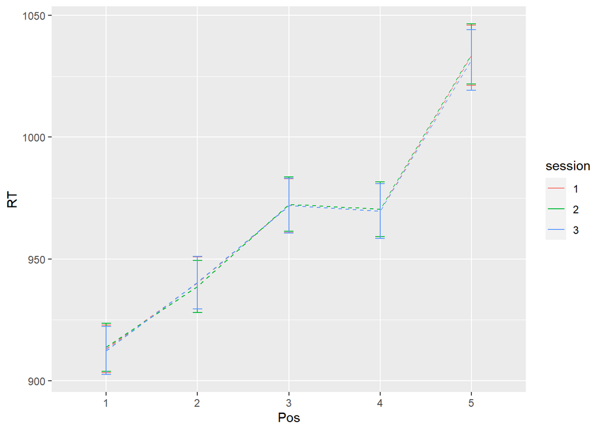

```r
ggplot(data=summary, aes(x=Pos, y=RT, group=session,
                         color = session)) +
    geom_line(aes(y = RT),
              size = 0.5, linetype = "dashed")+
    geom_errorbar(aes(ymin=RT-se, ymax=RT+se), width =.1)
```

## 1) Set up a model based on the structure of the planned CSI experiment

Unfortunately, simr does not work properly with GLMMs. Therefore, for the power analysis, we will set up an LMM with transformed RTs  
a) center OrdPos (continuous predictor)

```r
# center continuous predictor
df %>% mutate(Pos.c=scale(as.numeric(as.character(Pos)),
                     center = TRUE, scale = FALSE)) -> df
```

2. Check distribution of RTs

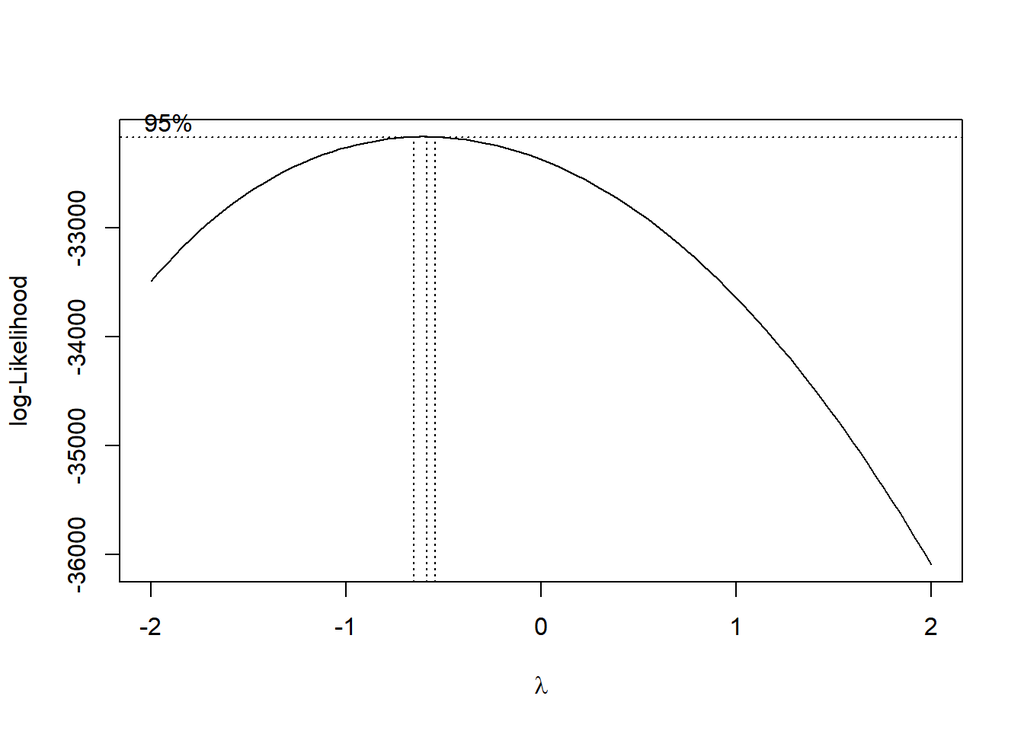

```r
# Boxcox plot suggests inverse transformation:
boxcox(df$RT ~ df$Pos*df$session)
```

Check the goodness of fit of an inverse transformation (with RT divided by 1000: 1/(x/1000) = 1000/x):

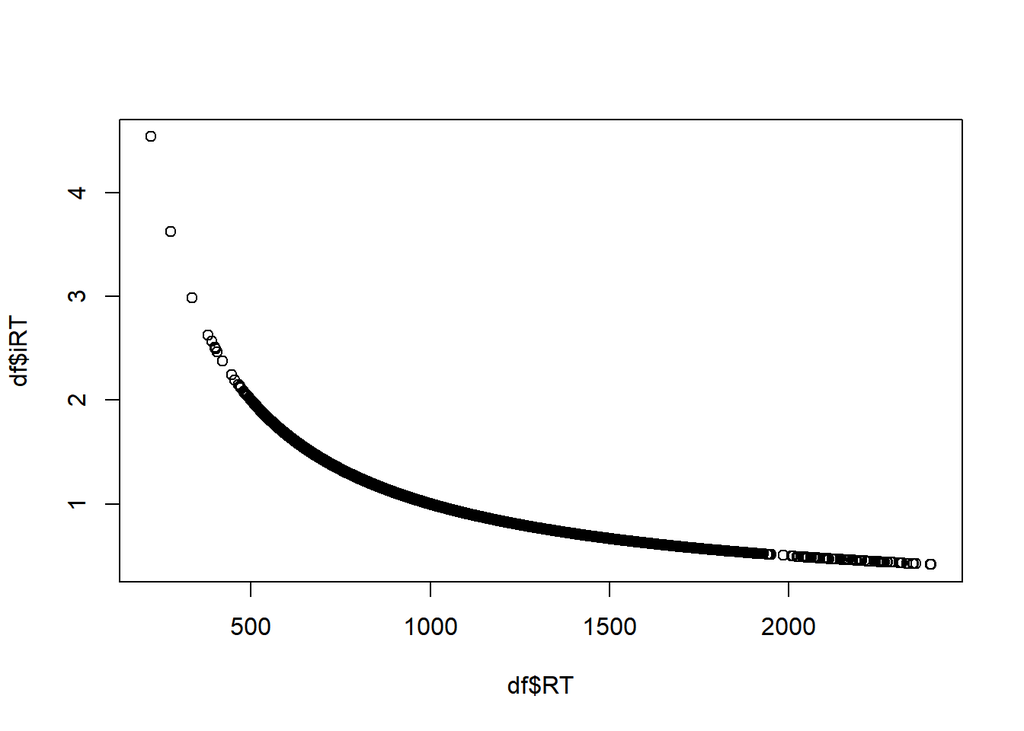

```r
df$iRT <-1000/df$RT
# plot this transformation distribution
plot(df$RT, df$iRT)
```

```r
# check fit
fit.normal_inv<- fitdistrplus::fitdist(
  df$iRT, distr = "norm", method = "mle")
summary(fit.normal_inv)
```

```
## Fitting of the distribution ' norm ' by maximum likelihood
## Parameters :
##       estimate  Std. Error
## mean 1.1199191 0.002999906
## sd   0.2968543 0.002121146
## Loglikelihood:  -2001.728   AIC:  4007.455   BIC:  4021.834
## Correlation matrix:
##      mean sd
## mean    1  0
## sd      0  1
```

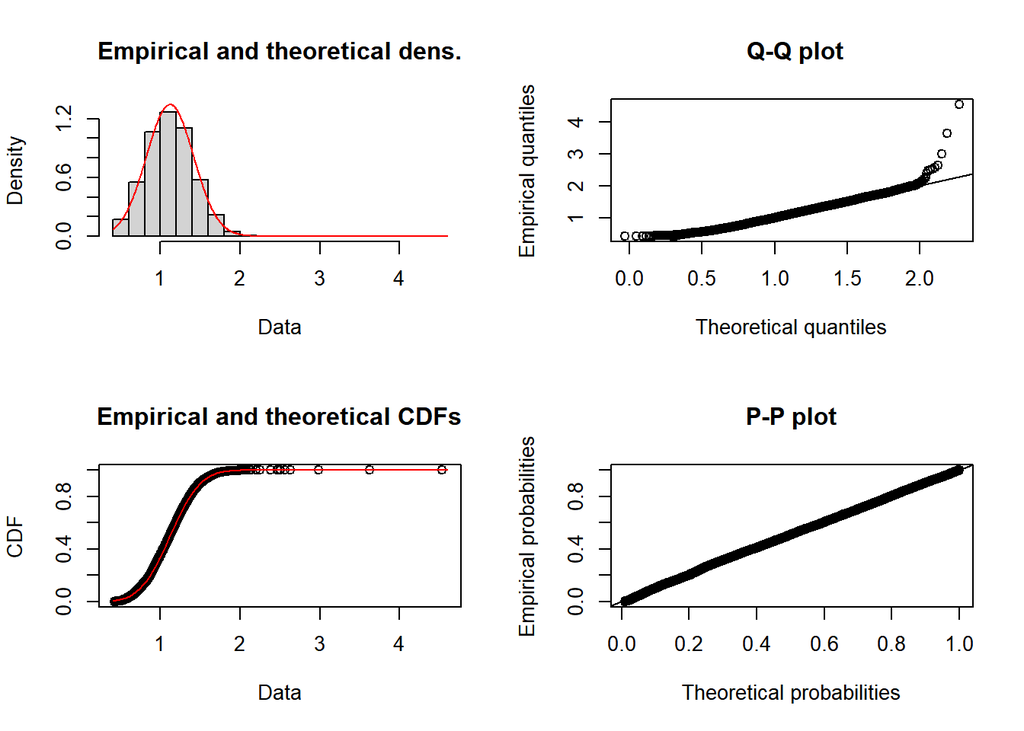

```r
plot(fit.normal_inv)
```

An inverse transformation fits the data relatively well. We will thus use this kind of transformation

3. Set up the models

*Model 1: Linear model with continuous predictor “Ordinal position”, sliding difference contrasted predictor “session” and inversely transformed RT data*

```r
# compute sliding difference contrast: Intercept is grand mean, second level is compared to first level
contrasts(df$session) <- contr.sdif(3)
# maximal model has singular fit - stepwise reduction
# lmm1 <- lmer(iRT ~ Pos.c*session +
#               (Pos.c*session|subject) +(Pos.c*session|category) ,
#            data = df, REML = FALSE,
#            control=lmerControl(optimizer = "bobyqa"))
# lmm1 <- lmer(iRT ~ Pos.c*session +
#               (Pos.c*session|subject) +(Pos.c*session|category) ,
#            data = df, REML = FALSE,
#            control=lmerControl(optimizer = "bobyqa",
#                                 optCtrl=list(maxfun=2e5)))
lmm1 <- lmer(iRT ~ Pos.c*session +
              (Pos.c|subject) +(Pos.c|category) ,
           data = df, REML = FALSE,
           control=lmerControl(optimizer = "bobyqa",
                                optCtrl=list(maxfun=2e5)))

isSingular(lmm1)
```

```
## [1] FALSE
```

```r
summary(lmm1)
```

```
## Linear mixed model fit by maximum likelihood . t-tests use Satterthwaite's
##   method [lmerModLmerTest]
## Formula: iRT ~ Pos.c * session + (Pos.c | subject) + (Pos.c | category)
##    Data: df
## Control: lmerControl(optimizer = "bobyqa", optCtrl = list(maxfun = 2e+05))
##
##      AIC      BIC   logLik deviance df.resid
##    997.6   1091.1   -485.8    971.6     9779
##
## Scaled residuals:
##     Min      1Q  Median      3Q     Max
## -3.1714 -0.6162  0.0249  0.6353 12.6672
##
## Random effects:
##  Groups   Name        Variance  Std.Dev. Corr
##  subject  (Intercept) 0.0129952 0.11400
##           Pos.c       0.0003833 0.01958  -0.31
##  category (Intercept) 0.0102830 0.10140
##           Pos.c       0.0004107 0.02027  0.27
##  Residual             0.0626306 0.25026
## Number of obs: 9792, groups:  subject, 30; category, 24
##
## Fixed effects:
##                    Estimate Std. Error         df t value Pr(>|t|)
## (Intercept)       1.111e+00  2.946e-02  5.172e+01  37.696  < 2e-16 ***
## Pos.c            -2.913e-02  5.757e-03  4.200e+01  -5.059 8.79e-06 ***
## session2-1        8.765e-04  6.195e-03  9.685e+03   0.141    0.887
## session3-2        1.270e-03  6.195e-03  9.685e+03   0.205    0.838
## Pos.c:session2-1 -5.535e-04  4.389e-03  9.685e+03  -0.126    0.900
## Pos.c:session3-2  6.310e-04  4.389e-03  9.685e+03   0.144    0.886
## ---
## Signif. codes:  0 '***' 0.001 '**' 0.01 '*' 0.05 '.' 0.1 ' ' 1
##
## Correlation of Fixed Effects:
##             (Intr) Pos.c  sss2-1 sss3-2 P.:2-1
## Pos.c       -0.002
## session2-1   0.000  0.000
## session3-2   0.000  0.000 -0.500
## Ps.c:sss2-1  0.000  0.000  0.000  0.000
## Ps.c:sss3-2  0.000  0.000  0.000  0.000 -0.500
```

### 2) Extend dataset

In this case we want less subjects than in the previous study, so we do not need to extend.

### 3) Specify effect sizes for the interaction effect and compute power analyses

To specify the effect sizes, we always take the grand mean and take +- 1/2 the inversely transformed difference we want to implement. We keep the two main effects unchanged.

#### 16 ms interaction effect, 20 VP

```r
gm <- mean(df$RT)
eff_16ms <- (1000/(gm+(16/2))) - (1000/(gm-(16/2)))
fixef(lmm1)["Pos.c:session2-1"]<- eff_16ms
fixef(lmm1)["Pos.c:session3-2"]<- eff_16ms
```

```r
PowerLMM_16_21 <- powerCurve(lmm1,along = "subject",
                                 test=fixed("Pos.c:session2-1","t"),
                          breaks = c(20), nsim = n_iter)
lastResult()$warnings
lastResult()$errors
```

```r
PowerLMM_16_21
```

```
## Power for predictor 'Pos.c:session2-1', (95% confidence interval),
## by number of levels in subject:
##      20: 91.00% (83.60, 95.80) - 6546 rows
##
## Time elapsed: 0 h 2 m 20 s
```

```r
PowerLMM_16_32 <- powerCurve(lmm1,along = "subject",
                                 test=fixed("Pos.c:session3-2","t"),
                          breaks = c(20), nsim = n_iter)
lastResult()$warnings
lastResult()$errors
```

```r
PowerLMM_16_32
```

```
## Power for predictor 'Pos.c:session3-2', (95% confidence interval),
## by number of levels in subject:
##      20: 90.00% (82.38, 95.10) - 6546 rows
##
## Time elapsed: 0 h 2 m 20 s
```

#### 15 ms interaction effect, 20 VP

```r
gm <- mean(df$RT)
eff_15ms <- (1000/(gm+(15/2))) - (1000/(gm-(15/2)))
fixef(lmm1)["Pos.c:session2-1"]<- eff_15ms
fixef(lmm1)["Pos.c:session3-2"]<- eff_15ms
```

```r
PowerLMM_15_21 <- powerCurve(lmm1,along = "subject",
                                 test=fixed("Pos.c:session2-1","t"),
                          breaks = c(20), nsim = n_iter)
lastResult()$warnings
lastResult()$errors
```

```r
PowerLMM_15_21
```

```
## Power for predictor 'Pos.c:session2-1', (95% confidence interval),
## by number of levels in subject:
##      20: 88.00% (79.98, 93.64) - 6546 rows
##
## Time elapsed: 0 h 2 m 25 s
```

```r
PowerLMM_15_32 <- powerCurve(lmm1,along = "subject",
                                 test=fixed("Pos.c:session3-2","t"),
                          breaks = c(20), nsim = n_iter)
lastResult()$warnings
lastResult()$errors
```

```r
PowerLMM_15_32
```

```
## Power for predictor 'Pos.c:session3-2', (95% confidence interval),
## by number of levels in subject:
##      20: 88.00% (79.98, 93.64) - 6546 rows
##
## Time elapsed: 0 h 2 m 24 s
```

#### 14 ms interaction effect, 20 VP

```r
gm <- mean(df$RT)
eff_14ms <- (1000/(gm+(14/2))) - (1000/(gm-(14/2)))
fixef(lmm1)["Pos.c:session2-1"]<- eff_14ms
fixef(lmm1)["Pos.c:session3-2"]<- eff_14ms
```

```r
PowerLMM_14_21 <- powerCurve(lmm1,along = "subject",
                                 test=fixed("Pos.c:session2-1","t"),
                          breaks = c(20), nsim = n_iter)
lastResult()$warnings
lastResult()$errors
```

```r
PowerLMM_14_21
```

```
## Power for predictor 'Pos.c:session2-1', (95% confidence interval),
## by number of levels in subject:
##      20: 76.00% (66.43, 83.98) - 6546 rows
##
## Time elapsed: 0 h 2 m 21 s
```

```r
PowerLMM_14_32 <- powerCurve(lmm1,along = "subject",
                                 test=fixed("Pos.c:session3-2","t"),
                          breaks = c(20), nsim = n_iter)
lastResult()$warnings
lastResult()$errors
```

```r
PowerLMM_14_32
```

```
## Power for predictor 'Pos.c:session3-2', (95% confidence interval),
## by number of levels in subject:
##      20: 85.00% (76.47, 91.35) - 6546 rows
##
## Time elapsed: 0 h 2 m 22 s
```

#### 13 ms interaction effect, 20 VP

```r
gm <- mean(df$RT)
eff_13ms <- (1000/(gm+(13/2))) - (1000/(gm-(13/2)))
fixef(lmm1)["Pos.c:session2-1"]<- eff_13ms
fixef(lmm1)["Pos.c:session3-2"]<- eff_13ms
```

```r
PowerLMM_13_21 <- powerCurve(lmm1,along = "subject",
                                 test=fixed("Pos.c:session2-1","t"),
                          breaks = c(20), nsim = n_iter)
lastResult()$warnings
lastResult()$errors
```

```r
PowerLMM_13_21
```

```
## Power for predictor 'Pos.c:session2-1', (95% confidence interval),
## by number of levels in subject:
##      20: 80.00% (70.82, 87.33) - 6546 rows
##
## Time elapsed: 0 h 2 m 21 s
```

```r
PowerLMM_13_32 <- powerCurve(lmm1,along = "subject",
                                 test=fixed("Pos.c:session3-2","t"),
                          breaks = c(20), nsim = n_iter)
lastResult()$warnings
lastResult()$errors
```

```r
PowerLMM_13_32
```

```
## Power for predictor 'Pos.c:session3-2', (95% confidence interval),
## by number of levels in subject:
##      20: 83.00% (74.18, 89.77) - 6546 rows
##
## Time elapsed: 0 h 2 m 20 s
```

### Calculate effect size for interaction effect

```r
# x <- summary(lmm1)
randomvars <-  0.0130899+0.0003685+0.0102540+0.0004281+0.0621335
 (d_16 <- eff_16ms /sqrt(randomvars))
```

```
## [1] -0.0585144
```

```r
 (d_15 <- eff_15ms /sqrt(randomvars))
```

```
## [1] -0.05485679
```

```r
 (d_13 <- eff_13ms /sqrt(randomvars))
```

```
## [1] -0.04754184
```

## 4) Calculate the power for the ordinal position effect at an interaction effect of 15 ms

```r
gm <- mean(df$RT)
eff_15ms <- (1000/(gm+(15/2))) - (1000/(gm-(15/2)))
fixef(lmm1)["Pos.c:session2-1"]<- eff_15ms
fixef(lmm1)["Pos.c:session3-2"]<- eff_15ms
```

```r
PowerLMM_Pos.c <- powerCurve(lmm1,along = "subject",
                                 test=fixed("Pos.c","t"),
                          breaks = c(20), nsim = n_iter)
lastResult()$warnings
lastResult()$errors
```

```r
PowerLMM_Pos.c
```

```
## Power for predictor 'Pos.c', (95% confidence interval),
## by number of levels in subject:
##      20: 99.10% (98.30, 99.59) - 6546 rows
##
## Time elapsed: 0 h 23 m 38 s
```